# Tree-Based & Ensemble Methods

Pouria

4/25/2022

# Libraries

```r
# library(ISLR)
library(MASS)
library(tree)
library(randomForest)
library(magrittr)
library(ggplot2)
library(dplyr)
library(tidyr)
```

# Aim

We aim to gain hands-on experience with tree-based regression and ensemble methods on `Boston` data set to predict `medv` as a function of all other variables.

You may access `Boston` within the library `MASS`.

# Set seed

```r
set.seed(123)
```

# a) Split the data

Split the into training and test sets with the train-to-test ratio of 80%/20%.

```r
data = Boston
dim(Boston)
```

```
## [1] 506  14
```

```r
train.size <- nrow(data)*0.80
train <- sample(nrow(data), train.size)

Boston.train <- data[train,]
Boston.test  <- data[-train,]
```

# b) Fit a regression tree and plot - Prompt

- Fit a tree onto the data and print the summary.
- Visualize the tree.
- Obtain the test MSE for the full tree.

# b) Fit a regression tree and plot

1. Fit a tree and print the summary

```r
tree.Boston <- tree(medv ~ ., data = Boston.train)
summary(tree.Boston)
```

```
##
## Regression tree:
## tree(formula = medv ~ ., data = Boston.train)
## Variables actually used in tree construction:
## [1] "rm"    "lstat" "dis"   "crim"
## Number of terminal nodes:  8
## Residual mean deviance:  15.15 = 5997 / 396
## Distribution of residuals:
##     Min.  1st Qu.   Median     Mean  3rd Qu.     Max.
## -23.5800  -2.3090   0.1121   0.0000   2.2110  15.9300
```

# b) Fit a regression tree and plot

2. Plot the tree

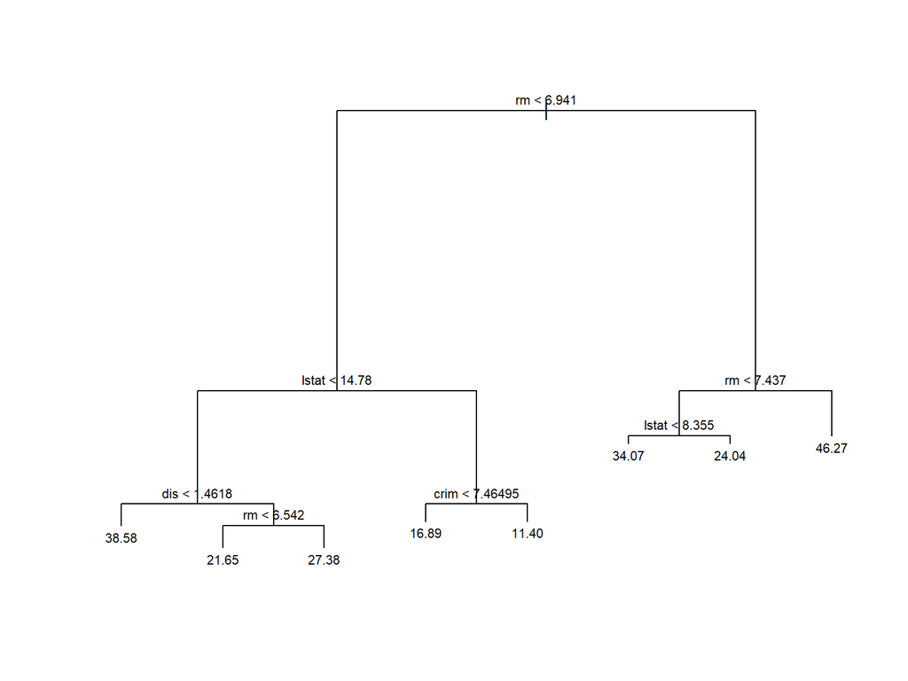

```r
plot(tree.Boston)
text(tree.Boston, pretty = 0, cex = 0.7)
```

# b) Fit a regression tree and plot

2. Plot the tree; alternative way using libraries `rpart` and `rpart.plot`.

**Note**: There are a lot of other relevant libraries and functions; `ggparty`, `partykit`, `ctree()`, if you are interested.

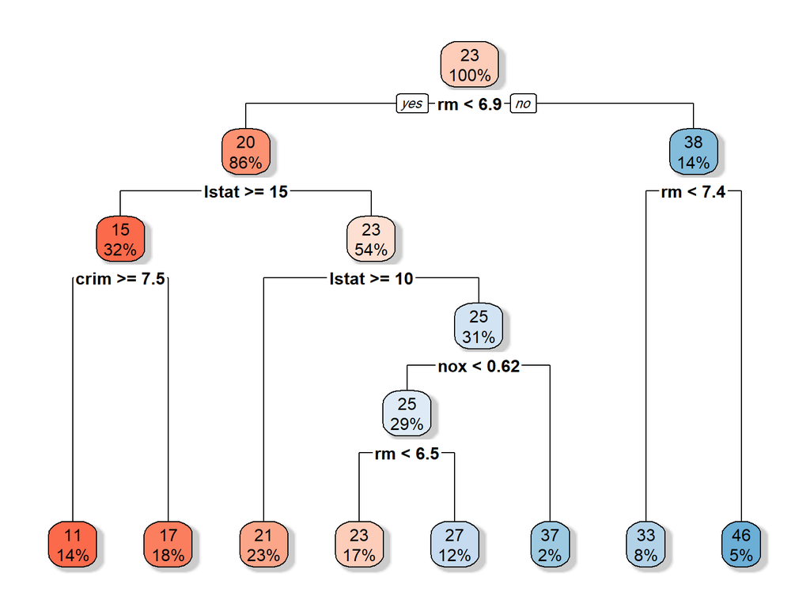

# b) Fit a regression tree and plot

3. Obtain the test MSE for this full tree.

```r
yhat <- predict(tree.Boston, newdata = Boston.test)
mean((yhat - Boston.test$medv)^2)
```

```
## [1] 22.29913
```

# c) Cross-Validation - Pruning - Prompt

- Perform cross-validation on the tree.
- Plot Deviance (`dev`) as a function of tree size.
- Plot the test MSE alongside the CV MSE and training MSE across tree size.
- Prune the tree with the best parameter, and print a summary of the output, and visualize the tree.
- Output the test MSE for the best pruned tree.

# c) Cross-Validation - Pruning

1. Perform cross-validation on the tree and print the output.

```r
cv.Boston <- cv.tree(tree.Boston)
cv.Boston
```

```
## $size
## [1] 8 7 6 4 3 2 1
##
## $dev
## [1]  8960.407  9027.983 10774.426 11149.794 13171.652 22238.037 34330.960
##
## $k
## [1]       -Inf   428.9448   963.6340  1207.4832  2499.1797  6271.6564 15532.4032
##
## $method
## [1] "deviance"
##
## attr(,"class")
## [1] "prune"         "tree.sequence"
```

# c) Cross-Validation - Pruning

2. Plot the results of the CV and show on the plot the tree size that corresponds to the best (least) CV error (`dev`).

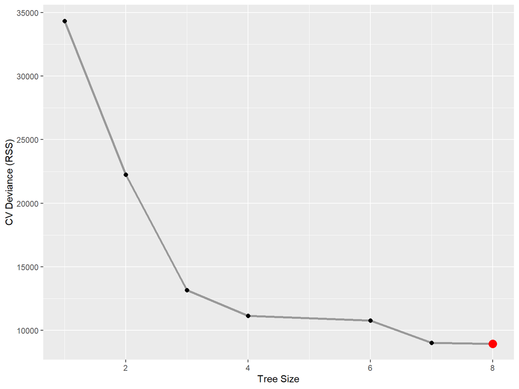

```r
tree.min <- which.min(cv.Boston$dev)

df.cv <- data.frame(size = cv.Boston$size,
                    dev = cv.Boston$dev)

df.cv %>%
  ggplot(aes(size, dev))+
  geom_line(size=1.1, col="grey60") +
  geom_point(size=2) +
  geom_point(aes(size[tree.min], dev[tree.min]), col = "red", size=4) +
  xlab("Tree Size") +
  ylab("CV Deviance (RSS)")
```

# c) Cross-Validation - Pruning

# c) Cross-Validation - Pruning

3. Plot the test MSE alongside the CV MSE and training MSE across tree size.

*Note*: For CV MSE, you may use the deviance output, but also ensure to divide it by `train.size`.

```r
tree.size.len <- length(cv.Boston$size)
tree.testMSE.arr <- array(rep(0,tree.size.len))
tree.trainMSE.arr <- array(rep(0,tree.size.len))

for (i in seq(tree.size.len-1,1,by=-1)){
  prune1.Boston <- prune.tree(tree.Boston, best = cv.Boston$size[i])
  yhat <- predict(prune1.Boston, newdata = Boston.test)
  tree.testMSE.arr[i] = mean((yhat - Boston.test$medv)^2)
  yhat <- predict(prune1.Boston, newdata = Boston.train)
  tree.trainMSE.arr[i] = mean((yhat - Boston.train$medv)^2)
}

tree.testMSE.arr[tree.size.len] <- var(Boston.test$medv)

tree.trainMSE.arr[tree.size.len] = var(Boston.test$medv)
```

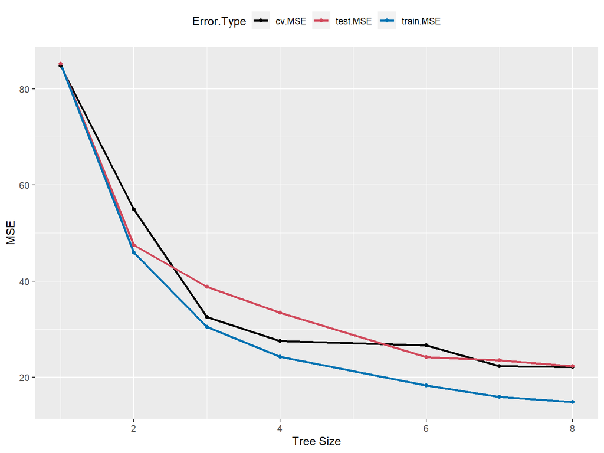

```r
data.frame(size = df.cv$size,
           train.MSE= tree.trainMSE.arr,
           cv.MSE = df.cv$dev/(train.size),
           test.MSE = tree.testMSE.arr) %>%
  pivot_longer(cols=2:4, names_to = "Error.Type", values_to = "Error.Value") %>%
  ggplot(aes(size, Error.Value, col=Error.Type)) +
  geom_line(size=1.05) +
  geom_point(size=1.5) +
  scale_color_manual(values=c("black", "#d1495b", "#0072B2")) +
  theme(legend.position = "top") +
  xlab("Tree Size") +
  ylab("MSE")
```

# c) Cross-Validation - Pruning

4. Prune the tree with the best parameter selected above, and print a summary of the output.

```r
# prune.Boston <- prune.tree(tree.Boston, best = cv.Boston$size[tree.min])
prune.Boston <- prune.tree(tree.Boston, best = 20)
summary(prune.Boston)
```

```
##
## Regression tree:
## tree(formula = medv ~ ., data = Boston.train)
## Variables actually used in tree construction:
## [1] "rm"    "lstat" "dis"   "crim"
## Number of terminal nodes:  8
## Residual mean deviance:  15.15 = 5997 / 396
## Distribution of residuals:
##     Min.  1st Qu.   Median     Mean  3rd Qu.     Max.
## -23.5800  -2.3090   0.1121   0.0000   2.2110  15.9300
```

# c) Cross-Validation - Pruning

5. Visualize the pruned tree.

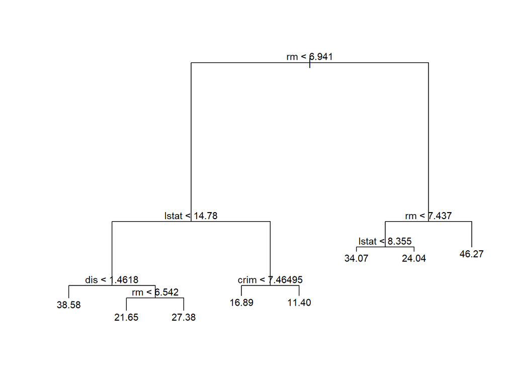

```r
plot(prune.Boston)
text(prune.Boston, pretty = 0, cex = 0.9)
```

# c) Cross-Validation - Pruning

6. Obtain the test MSE for the best pruned model.

```r
yhat <- predict(prune.Boston, newdata = Boston.test)
mean((yhat - Boston.test$medv)^2)
```

```
## [1] 22.29913
```

# d) Bagging - Prompt

- Use the bagging approach in order to analyze this data.
- What test MSE do you obtain?
- Use the `importance()` function to determine which variables are most important.
- Plot the importance values in a bar plot.

# d) Bagging

1. Perform bagging and print the output

```r
p <- ncol(Boston) - 1

bag.Boston <- randomForest(medv ~ ., data = Boston.train, mtry = p)
# bag.Boston <- randomForest(medv ~ ., data = Boston.train,ntree=1000, mtry = p)
bag.Boston
```

```
##
## Call:
##  randomForest(formula = medv ~ ., data = Boston.train, mtry = p)
##                Type of random forest: regression
##                      Number of trees: 500
## No. of variables tried at each split: 13
##
##           Mean of squared residuals: 10.47835
##                     % Var explained: 87.59
```

# d) Bagging

1. Look into the bagging output; what are the MSE values in that output? Print the mean and range of MSE. How do you compare this result to the MSE obtained from the pruned tree in (c)?

```r
mean(bag.Boston$mse)
```

```
## [1] 11.01913
```

```r
range(bag.Boston$mse)
```

```
## [1] 10.38399 24.30438
```

# d) Bagging

2. What test MSE do you obtain? Compare it with that obtained using the pruned tree in (c).

```r
yhat.bag <- predict(bag.Boston, newdata = Boston.test)
bag.test.mse <- mean((yhat.bag - Boston.test$medv)^2)
bag.test.mse
```

```
## [1] 14.4558
```

# d) Bagging

3. Use the `importance()` function to determine which variables are most important.

```r
bag.imp <- importance(bag.Boston)
bag.imp
```

```
##         IncNodePurity
## crim       1314.81237
## zn           30.54343
## indus       167.34521
## chas         31.17467
## nox         514.73159
## rm        14371.72542
## age         437.95328
## dis        2159.73191
## rad          92.19548
## tax         554.95752
## ptratio     494.69740
## black       268.13531
## lstat     13187.62469
```

# d) Bagging

4. Plot the importance values in a bar plot.

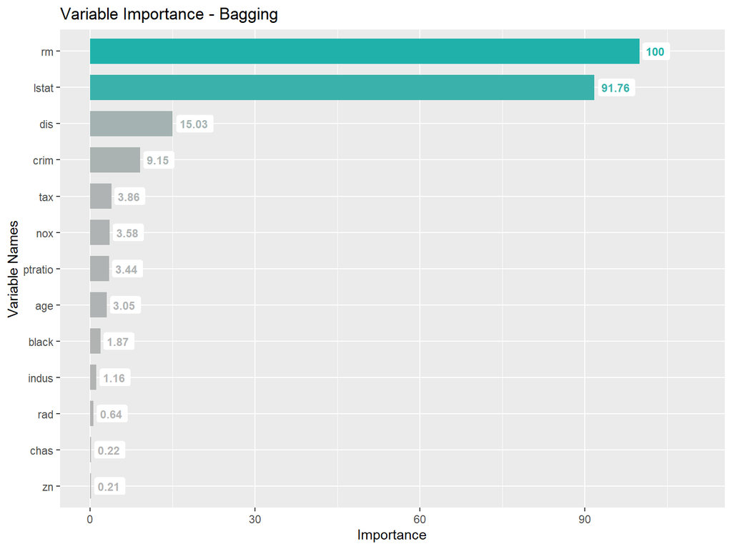

```r
data.frame(bag.imp) %>%
  mutate(rowname = rownames(bag.imp)) %>%
  ggplot(aes(x = reorder(rowname, IncNodePurity), y = 100*IncNodePurity/max(IncNodePurity))) +
  geom_bar(stat = "identity", aes(fill = IncNodePurity), width=.7) +
  scale_fill_gradient(low = "grey70", high = "LightSeaGreen") +
  scale_color_gradient(low = "grey70", high = "LightSeaGreen") +
  scale_y_continuous(limits = c(0, 110))+
  coord_flip() +
  theme(legend.position = "none") +
  labs(title = "Boston Dataset - Random Forest - Variable Importance",
       x = "Variable Names",
       y = "Importance") +
  geom_label(
    aes(label = round(100*IncNodePurity/max(IncNodePurity),2), col = 100*IncNodePurity/max(IncNodePurity)),
    hjust = -.1, nudge_x = 0,
    size = 3.2, fontface = "bold",
    ## turn into white box without outline
    fill = "white", label.size = 0) +
  labs(title = "Variable Importance - Bagging",
       x = "Variable Names",
       y = "Importance") +
  theme_grey() +
  theme(legend.position = "none")
```

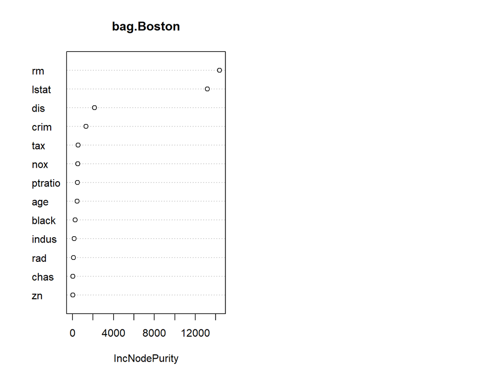

```r
par(mfrow=c(1,2))
varImpPlot (bag.Boston)
# plot(rf.imp)
```

# e) Random Forest - Prompt

- Use random forests to analyze this data.
- What test MSE do you obtain?
- Use the `importance()` function to determine which variables are most important.
- Describe the effect of m, the number of variables considered at each split, on the error rate obtained.

# e) Random Forest

1. Perform random forest and print the output

```r
rf.Boston <- randomForest(medv ~ ., data = Boston.train)
# rf.Boston <- randomForest(medv ~ ., mtry=8, data = Boston.train)

rf.Boston
```

```
##
## Call:
##  randomForest(formula = medv ~ ., data = Boston.train)
##                Type of random forest: regression
##                      Number of trees: 500
## No. of variables tried at each split: 4
##
##           Mean of squared residuals: 10.49785
##                     % Var explained: 87.57
```

# e) Random Forest

1. Look into the random forest output; what are the MSE values in that output? Print the mean and range of MSE. How do you compare this result to the MSE obtained from the pruned tree in (c) and bagging result in (d)?

```r
mean(rf.Boston$mse)
```

```
## [1] 11.38508
```

```r
range(rf.Boston$mse)
```

```
## [1] 10.30245 52.01848
```

# e) Random Forest

2. What **test MSE** do you obtain? Compare it with those obtained using the pruned tree in (c) and using Bagging in (d).

```r
yhat.rf <- predict(rf.Boston, newdata = Boston.test)
rf.test.mse <- mean((yhat.rf - Boston.test$medv)^2)
rf.test.mse
```

```
## [1] 11.64489
```

# e) Random Forest

3. Use the `importance()` function to determine which variables are most important.

```r
rf.imp <- importance(rf.Boston)
rf.imp
```

```
##         IncNodePurity
## crim        2117.0756
## zn           244.2836
## indus       1628.9852
## chas         156.8991
## nox         1972.1870
## rm          9500.2804
## age         1052.5975
## dis         2029.0782
## rad          282.6609
## tax         1025.1382
## ptratio     2449.4863
## black        569.8083
## lstat      10214.0509
```

# e) Random Forest

4. Plot the importance values in a bar plot.

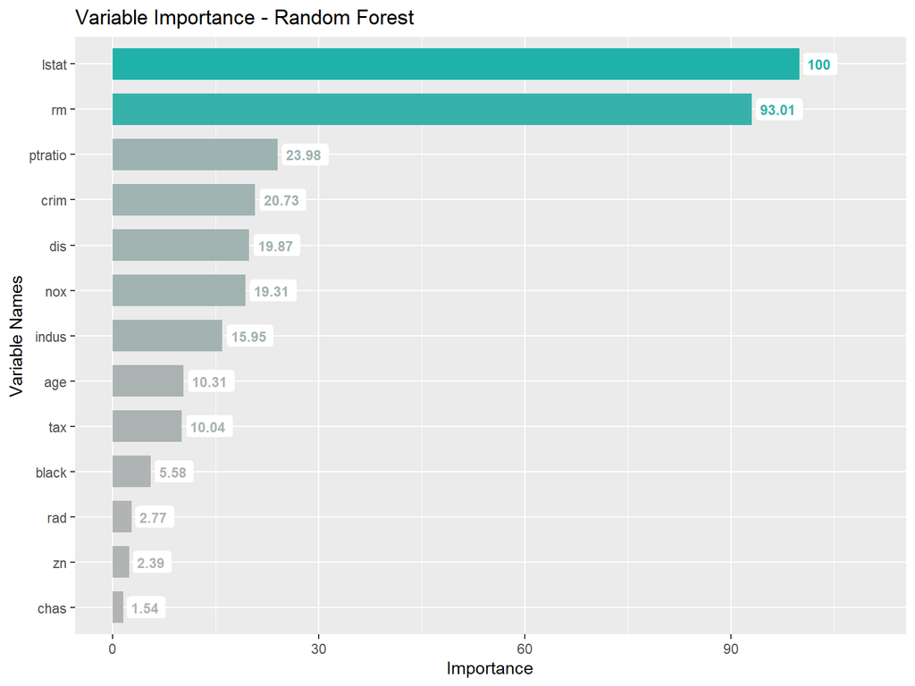

```r
data.frame(rf.imp) %>%
  mutate(rowname = rownames(rf.imp)) %>%
  ggplot(aes(x = reorder(rowname, IncNodePurity), y = 100*IncNodePurity/max(IncNodePurity))) +
  geom_bar(stat = "identity", aes(fill = IncNodePurity), width=.7) +
  scale_fill_gradient(low = "grey70", high = "LightSeaGreen") +
  scale_color_gradient(low = "grey70", high = "LightSeaGreen") +
  scale_y_continuous(limits = c(0, 110))+
  coord_flip() +
  theme(legend.position = "none") +
  labs(title = "Boston Dataset - Random Forest - Variable Importance",
       x = "Variable Names",
       y = "Importance") +
  geom_label(
    aes(label = round(100*IncNodePurity/max(IncNodePurity),2), col = 100*IncNodePurity/max(IncNodePurity)),
    hjust = -.1, nudge_x = 0,
    size = 3.2, fontface = "bold",
    ## turn into white box without outline
    fill = "white", label.size = 0) +
  labs(title = "Variable Importance - Random Forest",
       x = "Variable Names",
       y = "Importance") +
  theme_grey() +
  theme(legend.position = "none")
```

# f) Random Forest vs. Bagging - Make comments

- First, How is Random Forest different from Bagging in essence?
- Look back at both CV errors and test errors obtained using Random Forest and Bagging. How did using each of these ensemble methods change the fitting performance and predictive power of a single tree. Can you relate this to the effect of the number of variables considered at each split?